# IE582 Fall

```r
  print("Summary of MAPE for the hourly lasso regression:")
```

```
## [1] "Summary of MAPE for the hourly lasso regression:"
```

```r
  print(summary(MAPE_lasso))
```

```
##    Min. 1st Qu.  Median    Mean 3rd Qu.    Max.
## 0.01398 0.01532 0.01702 0.02476 0.03720 0.04686
```

Looking at the MAPE, it is seen that the best result is coming from lasso regression compared to other models. Similar to the hour-based linear regression, it is observed that the model error increases between the hours 8-17 in lasso regression.

The feature number used, that is, the total number of coefficients that are not 0, does not seem to depend on the time zone.

The number of nonzero coefficients would be less in general if lambda.1se was chosen. So the number of variables used by lambda.min is higher than lambda.1se, which increases complexity. Still, lambda.min is used to reduce the MAPE. Lambda.min takes value between 0.24 and 5.92.

# 5 PART F

## 5.1 Comparison of Results

**Boxplots with MAPE values**

Models were built on an hourly basis in part c and d, 24 performance results were obtained only in these parts. However, in other model types, only one model was established using all data. Therefore, one MAPE has been obtained. For this reason, it is possible to draw a boxplot only for lasso and linear regression using MAPE values.

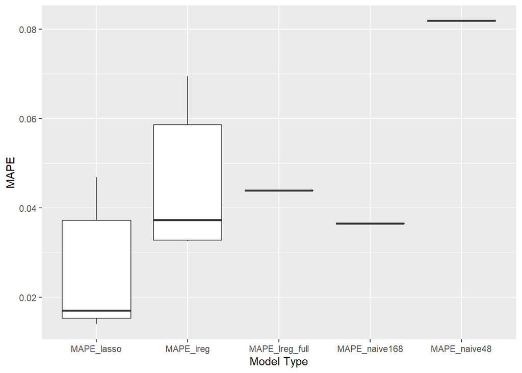

```r
MAPE_total<-data.frame(MAPE_naive48,MAPE_naive168,MAPE_lreg_full,MAPE_lreg,MAPE_lasso)
MAPE_total<-MAPE_total%>%pivot_longer(.,cols=-c(),names_to="Model Type",values_to="MAPE")
ggplot(MAPE_total, aes(x=`Model Type`, y=MAPE)) + geom_boxplot()
```

**Boxplots with APE values**

*Ape:* Absolute Percentage Error

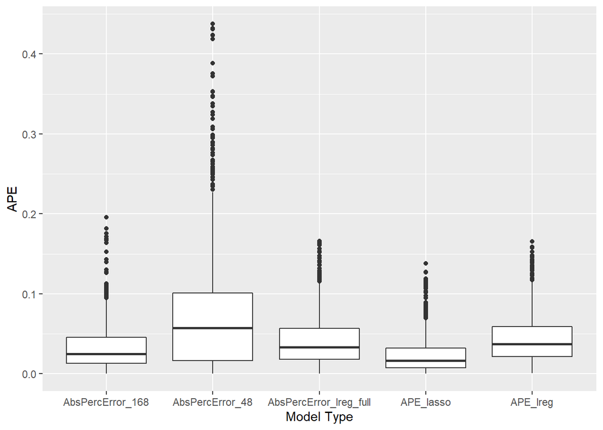

```r
AbsPercError<-data.frame(AbsPercError_48,AbsPercError_168,APE_lreg,APE_lasso,AbsPercError_lreg_full)
AbsPercError<-AbsPercError%>%pivot_longer(.,cols=-c(),names_to="Model Type",values_to="APE")
ggplot(AbsPercError, aes(x=`Model Type`, y=APE)) + geom_boxplot()
```

When the boxplots showing the distribution of MAPE values are examined, it is clear that lasso regression gives the best result and the worst result is reached with the naive approach with lag 48. It is not surprising that lasso regression works better, as the hourly electricity usage values during a day are interrelated. Lasso regression performs better as it penalizes the correlation between features, namely hourly consumption. Another result is that linear regression models established on an hourly basis give a better result than the linear regression model established using all data. The reason for this is the hourly seasonality. However, in general I can say it is not worth building linear regression model because it does not give a good result even as the naive approach with lag 168.

# 6 Appendices

- *1.* [Rmd file](https://bu-ie-582.github.io/fall20-fatmadumlupinar/files/HW3/IE582_HW3.Rmd) for the codes.